# Homework4

## Cell tracking with geomstats

### Rebecca Martin, Sam Rosen, Breanna Takacs, Gabriela V. Torres

## I. Motivation for cell tracker

### Cell migration in development and disease

1 In many animals, primordial germ cells migrate to the developing gonads which eventually form the ovaries in females and the testes in males.

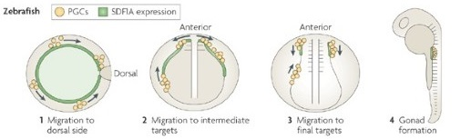

2 Metastasis occurs when cancer cells break away from the original tumor and spread to other parts of the body.

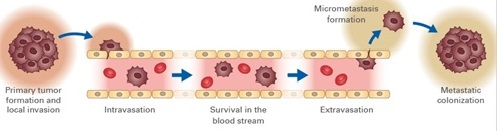

3 Via chemotaxis, immune cells can move from one site in the body to another to defend against infectious disease and foreign invaders.

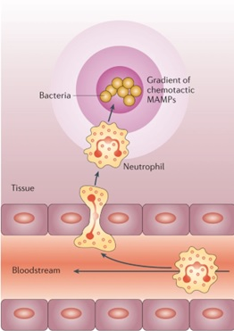

### II. Current cell tracking software:

CellProfiler -- open source

- Cell displacements, velocities, morphology, area, perimeter, solidity, form factor, eccentricity
- GUI based
- Can simultaneously measure size, shape, intensity; various cell types

ImarisTrack -- commercial

- Number of cells, cell centroid positions, cell surface areas (2D), cell volumes (3D), cell displacements, cell velocities, path curvature, number of fusions of tracks, number of divisions of cell track

CellPose -- open source

- A segmentation algorithm based on Deep-Learning techniques using cytoplasm
- Can be used for any cell type; not for real-time; developer friendly (python)

## III Motivation for geomstats cell tracker

### Current gaps in cell tracking software:

- post-video analysis
- 2D images
- rely on particular microscopy techniques
- inconsistent assignment and labeling

### How geomstats tracker would work:

- K means clustering to take into account multiple features when tracking a cell

### Geostats tracking will enable:

- Improve accuracy of distinguishing different cells
- Track cells live (i.e., have the microscope move around as the cell moves)
- Tracking in 3D images

## IV. Workflow

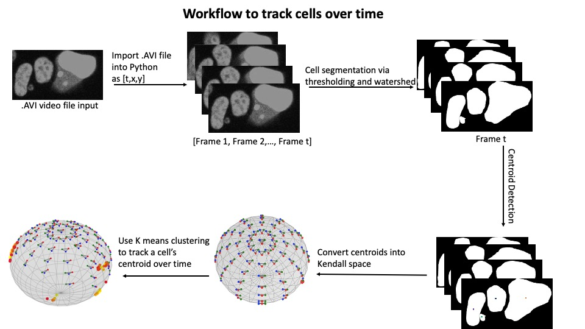

## V Coding geomstats tracker

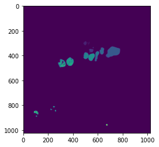

```python
plt.imshow(segmentation_movie[2])
```

```python
print(array[22][0:3])
```

```
[[295.48787529 507.3187067 ]
 [344.5964691  545.62421185]
 [356.586629   642.06826742]]
```

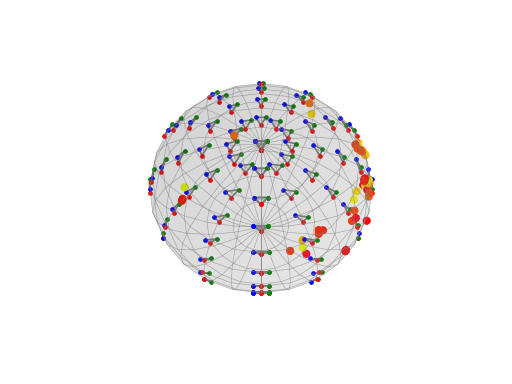

[figure not shown]

```
WARNING: No handles with labels found to put in legend.
```

```python
%matplotlib notebook
movie_to_kendall(array)
```

## VI. Conclusion

- We were able to more easily visualize centroid data in kendall space -- clusters are formed based on location
- In the future, we would use k-means clustering to assign labels to cells

## VII. References

Bloes, D., Kretschmer, D. & Peschel, A. Enemy attraction: bacterial agonists for leukocyte chemotaxis receptors. Nat Rev Microbiol 13, 95–104 (2015). https://doi.org/10.1038/nrmicro3390

Carpenter, A.E., Jones, T.R., Lamprecht, M.R. et al. CellProfiler: image analysis software for identifying and quantifying cell phenotypes. Genome Biol 7, R100 (2006). https://doi.org/10.1186/gb-2006-7-10-r100

Emami, N., Sedaei, Z. & Ferdousi, R. Computerized cell tracking: Current methods, tools and challenges. Visual Informaticshttps://doi.org/10.1016/j.visinf.2020.11.003 (2020).

Richardson, B., Lehmann, R. Mechanisms guiding primordial germ cell migration: strategies from different organisms. Nat Rev Mol Cell Biol 11, 37–49 (2010). https://doi.org/10.1038/nrm2815

Valastyan, S., & Weinberg, R. A. (2011). Tumor metastasis: molecular insights and evolving paradigms. Cell. 10.1016/J.CELL.2011.09.024